# Rosters and Units

Roman Rivera

1/20/2018

# Introduction

```r
prof <- read_csv("../../full-output/profiles/final-profiles.csv.gz") %>%
        mutate(gender = recode(gender,
                               MALE = 'Male', FEMALE = 'Female',
                               .default='Unknown'),
               race = recode(race,
                             BLACK = 'Black', HISPANIC = 'Hispanic', WHITE = 'White',
                             .default = 'Other'),
               resignation_date = ymd(resignation_date),
               appointed_date = ymd(appointed_date))
```

In the data we have collected, there are 33076 officers whose profiles have been aggregated across, at most, 15 files. These officers were appointed between March 4, 1936 and December 8, 2017, with 15 officers lacking appointed date information. Additionally, there are known resignation dates for 20,192 (61.05%) of officers, and imputed current (most recently known) units for 31,574 officers (95.46%). Race and gender information is known for 32,456 (98.13%) and 33,052 (99.93%), respectively. Birth year information is known for 32,537 (98.37%) officers. Full demographic (race, gender, birth year, appointed date) information exists for 32,439 (98.07%) of officers.

# Composition

The CPD has seen significant demographic shifts over the last 50 years. Looking at the racial and gender composition of officers based on the decade of their appointment…

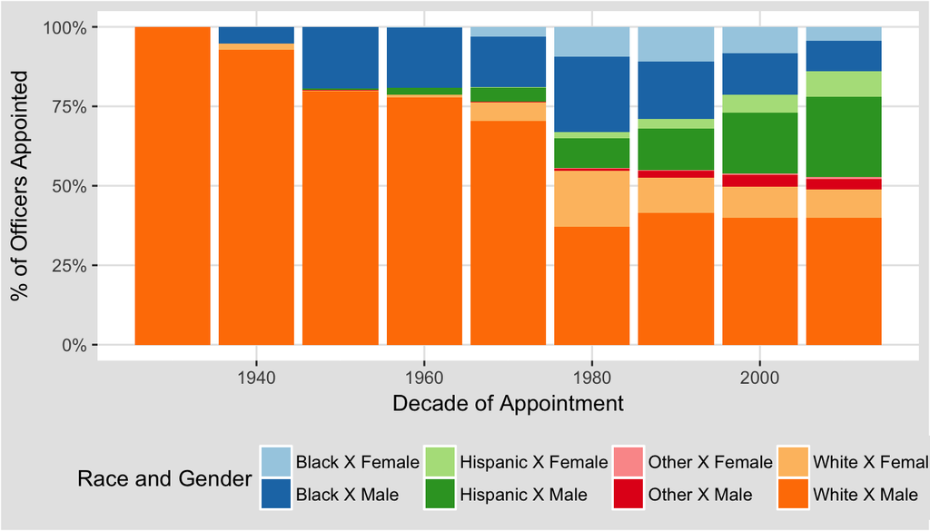

```r
prof %>%
  filter(! (is.na(appointed_date) | is.na(race) | is.na(gender))) %>%
  mutate(appointed_decade = ymd(paste0((year(appointed_date) %/% 10 * 10), '-01-01')),
         rxg = str_wrap(str_to_title(paste0(race, ' x ', gender)), width=30)) %>%
  ggplot(., aes(x = appointed_decade, fill = rxg)) +
  geom_bar(position='fill') +
  scale_y_continuous(labels=scales::percent) +
  scale_fill_brewer(palette="Paired") +
  theme(legend.position = 'bottom') +
  labs(x = 'Decade of Appointment', y = '% of Officers Appointed', fill='Race and Gender')
```

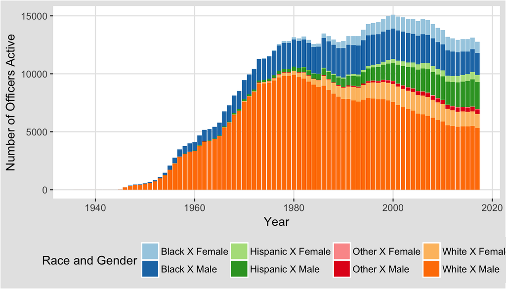

```r
proft <- prof %>%
  mutate(resignation_date = if_else(!is.na(resignation_date),
                                    ymd(resignation_date),
                                    ymd('2017-12-31')),
         start_year = year(appointed_date),
         end_year = year(resignation_date)) %>%
  filter(! is.na(start_year),
         start_year <= end_year,
         end_year < start_year + 50,
         ! is.na(race),
         ! is.na(gender)) %>%
  select(UID, race, gender, start_year, end_year) %>%
  mutate(active_dates = map2(start_year, end_year, seq)) %>%
  unnest() %>%
  mutate(active_dates = ymd(paste0(active_dates, '-01-01'))) %>%
  mutate(rxg = str_to_title(paste0(race, ' x ', gender)))

proft %>%
  ggplot(., aes(x=active_dates, fill=rxg)) +
  geom_bar() +
  scale_fill_brewer(palette="Paired") +
  theme(legend.position = 'bottom') +
  labs(x = 'Year', y='Number of Officers Active', fill='Race and Gender')
```

```r
proft %>%
  group_by(active_dates, race) %>% tally() %>%
  select(Year = active_dates, race, n) %>%
  spread(race, n)  %>%
  replace_na(list("Black" = 0, "Hispanic"=0, "Hispanic"=0,   "Other"=0, "White"=0)) %>%
  tk_xts(.) %>%
  dygraph() %>%
  dySeries("Black", label = "Black") %>%
  dySeries("White", label = "White") %>%
  dySeries("Hispanic", label = "Hispanic") %>%
  dySeries("Other", label = "Other") %>%
  dyLegend(width = 500) %>%
  dyRangeSelector(dateWindow = c(min(proft$active_dates), max(proft$active_dates)))
```

[interactive chart not shown]